# QMSS5074GR - Final Project (3rd)

### Your Grp ID: Group 3

### Your UNIs: xl3456, yz4661, lz3073

### Your Full Names: Xiaole Liu, Evan Zhou, Leizu Zhang

### Public GitHub Repo: https://github.com/DX0ZART/Group3

## Part 1 – Data Ingestion & Preprocessing

### 1.1 Data Loading

- Acquire the Stanford Sentiment Treebank dataset.
- Split into training, validation, and test sets with stratified sampling to preserve class balance.
- Clearly document your splitting strategy and resulting dataset sizes.

```python
import pandas as pd

import os
os.environ["TF_USE_LEGACY_KERAS"] = "1"

# IMPORT DATA
!git clone https://github.com/YJiangcm/SST-2-sentiment-analysis.git



df = pd.read_csv(
    "SST-2-sentiment-analysis/data/train.tsv",
    sep="\t",
    header=None,
    names=["label", "sentence"]
)

df.head()
```

```
fatal: destination path 'SST-2-sentiment-analysis' already exists and is not an empty directory.
```

|  | label | sentence |
| --- | --- | --- |
| 0 | 1 | a stirring , funny and finally transporting re... |
| 1 | 0 | apparently reassembled from the cutting-room f... |
| 2 | 0 | they presume their audience wo n't sit still f... |
| 3 | 1 | this is a visually stunning rumination on love... |
| 4 | 1 | jonathan parker 's bartleby should have been t... |

```python
# !pip install -q datasets scikit-learn pandas

from datasets import load_dataset
from sklearn.model_selection import train_test_split
import pandas as pd

SEED = 42
VAL_RATIO = 0.1

ds = load_dataset("glue", "sst2")

train_hf = ds["train"]
test_hf  = ds["validation"]

train_df = train_hf.to_pandas()[["sentence", "label"]]

train_idx, val_idx = train_test_split(
    train_df.index,
    test_size=VAL_RATIO,
    random_state=SEED,
    stratify=train_df["label"]
)

train_split = train_df.loc[train_idx].reset_index(drop=True)
val_split   = train_df.loc[val_idx].reset_index(drop=True)

test_split = test_hf.to_pandas()[["sentence", "label"]].reset_index(drop=True)

def summarize(name, df_):
    counts = df_["label"].value_counts().sort_index()
    props = (counts / len(df_)).round(4)
    summary = pd.DataFrame({"count": counts, "proportion": props})
    print(f"\n{name}: n={len(df_)}")
    print(summary)

print("=== Dataset sizes and class balance (stratified) ===")
summarize("TRAIN", train_split)
summarize("VALIDATION", val_split)
summarize("TEST (GLUE validation)", test_split)
```

```
=== Dataset sizes and class balance (stratified) ===

TRAIN: n=60614
       count  proportion
label
0      26802      0.4422
1      33812      0.5578

VALIDATION: n=6735
       count  proportion
label
0       2978      0.4422
1       3757      0.5578

TEST (GLUE validation): n=872
       count  proportion
label
0        428      0.4908
1        444      0.5092
```

### 1.2 Text Cleaning & Tokenization

- Implement a reusable preprocessing pipeline that handles:
  - HTML removal, lowercasing, punctuation stripping
  - Vocabulary pruning (e.g., rare words threshold)
  - Tokenization (character- or word-level)
- Expose this as a function/class so it can be saved and re-loaded for inference.

```python
import re
import pandas as pd
import joblib
from sklearn.feature_extraction.text import CountVectorizer

def clean_text(text):
    text = re.sub(r'<[^>]*>', '', str(text))
    text = re.sub(r'\W+', ' ', text.lower()).strip()
    return text

# 1) Clean ONCE
df["cleaned_sentence"] = df["sentence"].apply(clean_text)

# 2) Vectorizer
vectorizer = CountVectorizer(
    analyzer="word",
    token_pattern=r"(?u)\b\w+\b",
    min_df=2
)

X = vectorizer.fit_transform(df["cleaned_sentence"])

print("X shape:", X.shape)
print("Vocab size:", len(vectorizer.vocabulary_))

# 3) Save & reload
joblib.dump(vectorizer, "count_vectorizer.joblib")

loaded_vectorizer = joblib.load("count_vectorizer.joblib")
X_new = loaded_vectorizer.transform(["this movie was amazing"])

print("New sample shape:", X_new.shape)
```

```
X shape: (6920, 7169)
Vocab size: 7169
New sample shape: (1, 7169)
```

### 1.3 Feature Extraction

- **Traditional**: Build a TF-IDF vectorizer (or n-gram count) pipeline.
- **Neural**: Prepare sequences for embedding—pad/truncate to a fixed length.
- Save each preprocessor (vectorizer/tokenizer) to disk.

```python
from sklearn.feature_extraction.text import TfidfVectorizer
import joblib

# DROP EMPTY
texts = df["cleaned_sentence"].astype(str).str.strip()
texts = texts[texts != ""]

tfidf_vectorizer = TfidfVectorizer(
    max_features=5000,
    min_df=1,
    ngram_range=(1, 2),
    token_pattern=r"(?u)\b\w+\b"
)

X_tfidf = tfidf_vectorizer.fit_transform(texts)

print("TF-IDF shape:", X_tfidf.shape)
print("Vocab size:", len(tfidf_vectorizer.vocabulary_))

joblib.dump(tfidf_vectorizer, "tfidf_vectorizer.joblib")
```

```
TF-IDF shape: (6920, 5000)
Vocab size: 5000
```

```
['tfidf_vectorizer.joblib']
```

```python
from sklearn.feature_extraction.text import TfidfVectorizer
import joblib

# TF-IDF Vectorizer (word-level)
tfidf_vectorizer = TfidfVectorizer(
    max_features=5000,
    min_df=2,
    ngram_range=(1, 2),
    token_pattern=r"(?u)\b\w+\b"
)

# Fit on cleaned text
X_tfidf = tfidf_vectorizer.fit_transform(df["cleaned_sentence"])

print("TF-IDF shape:", X_tfidf.shape)

# Save vectorizer
joblib.dump(tfidf_vectorizer, "tfidf_vectorizer.joblib")

# Reload for inference
loaded_tfidf = joblib.load("tfidf_vectorizer.joblib")
X_new = loaded_tfidf.transform(["this movie was amazing"])

print("Inference shape:", X_new.shape)

from tensorflow.keras.preprocessing.text import Tokenizer
from tensorflow.keras.preprocessing.sequence import pad_sequences
import joblib

MAX_VOCAB = 20000
MAX_LEN = 100   # fixed sequence length

# Initialize tokenizer
tokenizer = Tokenizer(
    num_words=MAX_VOCAB,
    oov_token="<OOV>"
)

# Fit on cleaned text
tokenizer.fit_on_texts(df["cleaned_sentence"])

# Convert text to sequences
sequences = tokenizer.texts_to_sequences(df["cleaned_sentence"])

# Pad / truncate sequences
X_seq = pad_sequences(
    sequences,
    maxlen=MAX_LEN,
    padding="post",
    truncating="post"
)

print("Sequence shape:", X_seq.shape)

# Save tokenizer
joblib.dump(tokenizer, "neural_tokenizer.joblib")

# Reload for inference
loaded_tokenizer = joblib.load("neural_tokenizer.joblib")
new_seq = loaded_tokenizer.texts_to_sequences(
    ["this movie was amazing"]
)
new_seq = pad_sequences(new_seq, maxlen=MAX_LEN)

print("New sequence shape:", new_seq.shape)
```

```
TF-IDF shape: (6920, 5000)
Inference shape: (1, 5000)
```

[output not shown]

```
Sequence shape: (6920, 100)
New sequence shape: (1, 100)
```

## Part 2 – Exploratory Data Analysis (EDA)

### 2.1 Class Distribution

- Visualize the number of positive vs. negative reviews.
- Compute descriptive statistics on review lengths (mean, median, IQR).

```
sentiment
0    3310
1    3610
Name: count, dtype: int64
```

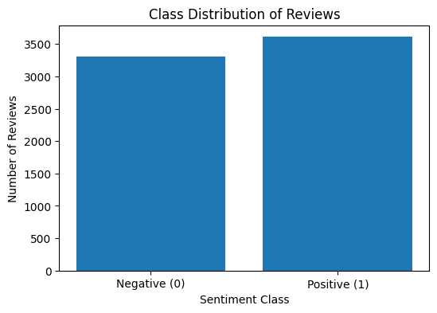

```python
import matplotlib.pyplot as plt
df = df.rename(columns= {'label' : 'sentiment'})
class_counts = df["sentiment"].value_counts().sort_index()
print(class_counts)



labels = ["Negative (0)", "Positive (1)"]
counts = class_counts.values

plt.figure(figsize=(6, 4))
plt.bar(labels, counts)
plt.title("Class Distribution of Reviews")
plt.ylabel("Number of Reviews")
plt.xlabel("Sentiment Class")
plt.show()
```

```
Mean review length: 19.32
Median review length: 19.00
IQR of review length: 13.00
```

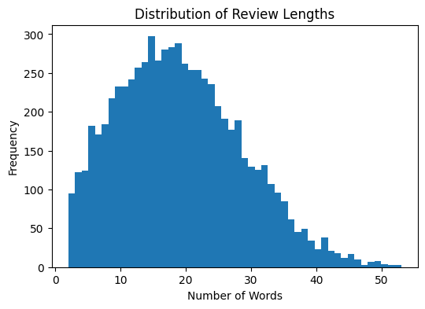

```python
df["review_length"] = df["sentence"].astype(str).apply(lambda x: len(x.split()))

mean_len = df["review_length"].mean()
median_len = df["review_length"].median()

q1 = df["review_length"].quantile(0.25)
q3 = df["review_length"].quantile(0.75)
iqr = q3 - q1

print(f"Mean review length: {mean_len:.2f}")
print(f"Median review length: {median_len:.2f}")
print(f"IQR of review length: {iqr:.2f}")

plt.figure(figsize=(6, 4))
plt.hist(df["review_length"], bins=50)
plt.title("Distribution of Review Lengths")
plt.xlabel("Number of Words")
plt.ylabel("Frequency")
plt.show()
```

**SUMMARY**

The dataset contains 6,920 reviews in total, with 3,610 positive (52.2%) and 3,310 negative (47.8%) samples. The class distribution is therefore approximately balanced, with only a slight predominance of positive reviews. This indicates that no severe class imbalance is present, and standard accuracy-based evaluation metrics are appropriate without the need for resampling or class reweighting.

The distribution of review lengths is right-skewed, with most reviews clustered between 10 and 30 words, and a long tail extending toward longer sentences (up to approximately 50+ words). The close proximity of the mean and median suggests that the majority of reviews are of moderate length, with relatively few extreme outliers.

### 2.2 Text Characteristics

- Plot the 20 most frequent tokens per sentiment class.
- Generate word clouds (or bar charts) highlighting key terms for each class.

```python
from sklearn.feature_extraction.text import CountVectorizer
import pandas as pd

# Split by sentiment
neg_texts = df[df["sentiment"] == 0]["cleaned_sentence"]
pos_texts = df[df["sentiment"] == 1]["cleaned_sentence"]

# Use CountVectorizer for token frequency
vectorizer = CountVectorizer(
    stop_words="english",

)

# Negative class
X_neg = vectorizer.fit_transform(neg_texts)
neg_freq = pd.DataFrame({
    "token": vectorizer.get_feature_names_out(),
    "count": X_neg.sum(axis=0).A1
}).sort_values(by="count", ascending=False).head(20)

# Positive class
X_pos = vectorizer.fit_transform(pos_texts)
pos_freq = pd.DataFrame({
    "token": vectorizer.get_feature_names_out(),
    "count": X_pos.sum(axis=0).A1
}).sort_values(by="count", ascending=False).head(20)

print("Top 20 tokens (Negative):")
print(neg_freq)

print("\nTop 20 tokens (Positive):")
print(pos_freq)
```

```
Top 20 tokens (Negative):
           token  count
5113       movie    479
2996        film    397
4556        like    260
4293        just    160
2290        does    145
6639         rrb    142
4682         lrb    141
622          bad    136
7535       story    127
8000        time    110
1260  characters    106
1520      comedy    104
3403        good     92
```

[output cut: 30 more lines]

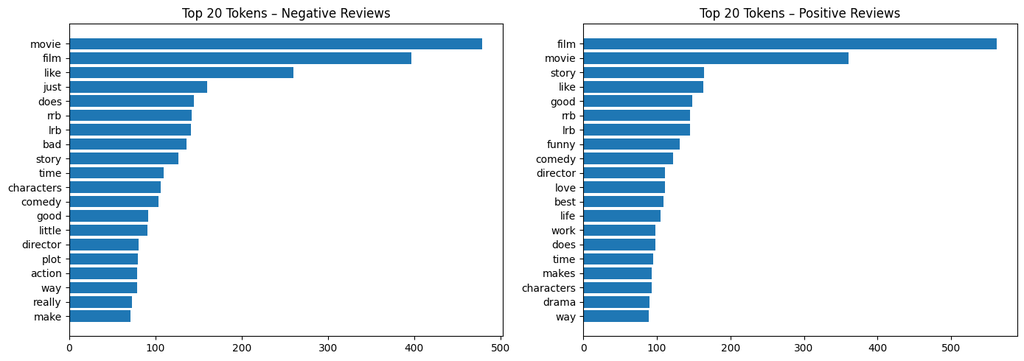

```python
import matplotlib.pyplot as plt

fig, axes = plt.subplots(1, 2, figsize=(14, 5))

axes[0].barh(neg_freq["token"], neg_freq["count"])
axes[0].set_title("Top 20 Tokens – Negative Reviews")
axes[0].invert_yaxis()

axes[1].barh(pos_freq["token"], pos_freq["count"])
axes[1].set_title("Top 20 Tokens – Positive Reviews")
axes[1].invert_yaxis()

plt.tight_layout()
plt.show()
```

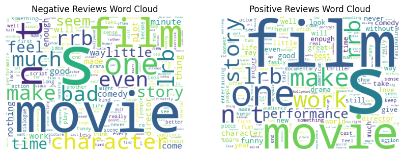

```python
from wordcloud import WordCloud

neg_text = " ".join(neg_texts)
pos_text = " ".join(pos_texts)

wc_neg = WordCloud(width=400, height=300, background_color="white").generate(neg_text)
wc_pos = WordCloud(width=400, height=300, background_color="white").generate(pos_text)

plt.figure(figsize=(10, 4))

plt.subplot(1, 2, 1)
plt.imshow(wc_neg)
plt.axis("off")
plt.title("Negative Reviews Word Cloud")

plt.subplot(1, 2, 2)
plt.imshow(wc_pos)
plt.axis("off")
plt.title("Positive Reviews Word Cloud")

plt.show()
```

### 2.3 Correlation Analysis

- Analyze whether review length correlates with sentiment.
- Present findings numerically and with at least one visualization.

```python
mean_length_by_class = df.groupby("sentiment")["review_length"].mean()
print(mean_length_by_class)

correlation = df["review_length"].corr(df["sentiment"])
print("Correlation between review length and sentiment:", correlation)
```

```
sentiment
0    19.197281
1    19.423546
Name: review_length, dtype: float64
Correlation between review length and sentiment: 0.012118445137412028
```

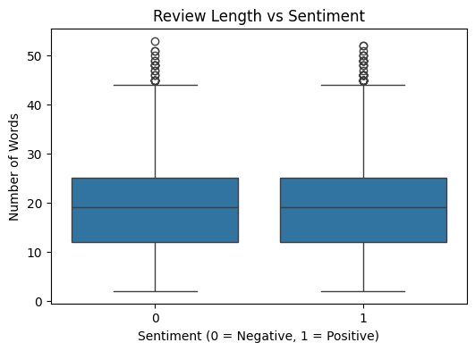

```python
import seaborn as sns
import matplotlib.pyplot as plt

plt.figure(figsize=(6, 4))
sns.boxplot(x="sentiment", y="review_length", data=df)
plt.title("Review Length vs Sentiment")
plt.xlabel("Sentiment (0 = Negative, 1 = Positive)")
plt.ylabel("Number of Words")
plt.show()
```

## Part 3 – Baseline Traditional Models

### 3.1 Logistic Regression & SVM

- Train at least two linear models on TF-IDF features.
- Use cross-validation (≥ 5 folds) on the training set to tune at least one hyperparameter.

```python
from sklearn.linear_model import LogisticRegression
from sklearn.svm import SVC
from sklearn.model_selection import cross_val_score

# Logistic Regression
logreg = LogisticRegression()
logreg_scores = cross_val_score(logreg, X, df['sentiment'], cv=5)

# SVM
svm = SVC()
svm_scores = cross_val_score(svm, X, df['sentiment'], cv=5)

# Print accuracy for both models
print("Logistic Regression Scores:", logreg_scores)
print("SVM Scores:", svm_scores)
```

```
Logistic Regression Scores: [0.79118497 0.76734104 0.78540462 0.7767341  0.80202312]
SVM Scores: [0.75216763 0.74638728 0.75722543 0.74638728 0.75794798]
```

```python
from sklearn.linear_model import LogisticRegression
from sklearn.svm import SVC
from sklearn.model_selection import cross_val_score
import numpy as np

# Labels
y = df["sentiment"]

# Hyperparameter candidates (for fine-tuning)
C_grid = [0.01, 0.1, 1, 10, 100]

print("starting to fine-tune logistic regression... best C")

best_lr_C = None
best_lr_score = -1

for C in C_grid:

    logreg = LogisticRegression(
        C=C,
        max_iter=1000,
        solver="liblinear"
    )

    # 5-fold cross-validation
    scores = cross_val_score(
        logreg,
        X,
        y,
        cv=5,
        scoring="accuracy"
    )

    mean_score = scores.mean()

    # Keep the best C
    if mean_score > best_lr_score:
        best_lr_score = mean_score
        best_lr_C = C

print(f"[Logistic Regression] Best C = {best_lr_C}, "
      f"Best CV Accuracy = {best_lr_score:.4f}")


print("starting to fine-tune svc... best C")
best_svm_C = None
best_svm_score = -1

for C in C_grid:

    svm = SVC(
        kernel="linear",
        C=C
    )

    # 5-fold cross-validation
    scores = cross_val_score(
        svm,
        X,
        y,
        cv=5,
        scoring="accuracy"
    )

    mean_score = scores.mean()

    # Keep the best C
    if mean_score > best_svm_score:
        best_svm_score = mean_score
        best_svm_C = C

print(f"[Linear SVM] Best C = {best_svm_C}, "
      f"Best CV Accuracy = {best_svm_score:.4f}")

print("comparison: ")

# Logistic Regression with best C
final_logreg = LogisticRegression(
    C=best_lr_C,
    max_iter=1000,
    solver="liblinear"
)
final_lr_scores = cross_val_score(final_logreg, X, y, cv=5)

# Linear SVM with best C
final_svm = SVC(kernel="linear", C=best_svm_C)
final_svm_scores = cross_val_score(final_svm, X, y, cv=5)

print("Final Logistic Regression CV scores:", final_lr_scores)
print("Final Linear SVM CV scores:", final_svm_scores)
```

```
starting to fine-tune logistic regression... best C
[Logistic Regression] Best C = 1, Best CV Accuracy = 0.7841
starting to fine-tune svc... best C
[Linear SVM] Best C = 0.1, Best CV Accuracy = 0.7828
comparison:
Final Logistic Regression CV scores: [0.79118497 0.76806358 0.78251445 0.7767341  0.80202312]
Final Linear SVM CV scores: [0.79046243 0.7767341  0.78395954 0.77745665 0.78540462]
```

### 3.2 Random Forest & Gradient Boosting

- Train two tree-based models on the same features.
- Report feature-importance for each and discuss any notable tokens.

```python
#random forest
from sklearn.ensemble import RandomForestClassifier
print("Training Random Forest...")

X = tfidf_vectorizer.fit_transform(df["cleaned_sentence"])
y = df["sentiment"].values

print("X.shape[1] =", X.shape[1])


from sklearn.ensemble import RandomForestClassifier
rf = RandomForestClassifier(n_estimators=200, random_state=42, n_jobs=-1)
rf.fit(X, y)


import pandas as pd
rf_top_features = pd.DataFrame({
    "token": tfidf_vectorizer.get_feature_names_out(),
    "importance": rf.feature_importances_
}).sort_values("importance", ascending=False).head(20)

print(rf_top_features)


#gradient boosting
from sklearn.ensemble import GradientBoostingClassifier
print("Training Gradient Boosting...")

gb = GradientBoostingClassifier(
    n_estimators=200,
    learning_rate=0.1,
    random_state=42
)

gb.fit(X, y)
gb_importance = gb.feature_importances_

gb_top_features = pd.DataFrame({
    "token": tfidf_vectorizer.get_feature_names_out(),
    "importance": gb.feature_importances_
}).sort_values("importance", ascending=False).head(20)


print("Top 20 important tokens (Gradient Boosting):")
print(gb_top_features)
```

```
Training Random Forest...
X.shape[1] = 5000
      token  importance
336     and    0.013427
4499    too    0.010393
21        a    0.010366
2910     of    0.008761
4156    the    0.008577
4417     to    0.006905
2203     is    0.006836
565     bad    0.006437
3496      s    0.005956
2252     it    0.005789
2442   like    0.005432
2714  movie    0.005229
```

[output cut: 31 more lines]

### 3.3 Evaluation Metrics

- Compute accuracy, precision, recall, F1-score, and ROC-AUC on the held-out test set.
- Present all results in a single comparison table.

```python
import re

def clean_text(text):
    text = re.sub(r'<[^>]*>', '', str(text))
    text = re.sub(r'\W+', ' ', text.lower()).strip()
    return text

def get_label_series(df_):
    if "sentiment" in df_.columns:
        return df_["sentiment"]
    if "label" in df_.columns:
        return df_["label"]
    raise KeyError("Neither 'sentiment' nor 'label' exists in the dataframe.")

y_train = get_label_series(train_split).values
y_test  = get_label_series(test_split).values


if "cleaned_sentence" not in train_split.columns:
    train_split["cleaned_sentence"] = train_split["sentence"].apply(clean_text)

if "cleaned_sentence" not in test_split.columns:
    test_split["cleaned_sentence"] = test_split["sentence"].apply(clean_text)



def ensure_cleaned_sentence(df_):
    if "cleaned_sentence" not in df_.columns:
        df_["cleaned_sentence"] = df_["sentence"].apply(clean_text)
    return df_

train_split = ensure_cleaned_sentence(train_split)
test_split  = ensure_cleaned_sentence(test_split)
```

```python
import numpy as np
import pandas as pd
from sklearn.metrics import accuracy_score, precision_score, recall_score, f1_score, roc_auc_score
from sklearn.linear_model import LogisticRegression
from sklearn.svm import SVC
from sklearn.ensemble import RandomForestClassifier, GradientBoostingClassifier

# Fit TF-IDF on TRAIN only (important)
X_train = tfidf_vectorizer.fit_transform(train_split["cleaned_sentence"])
X_test  = tfidf_vectorizer.transform(test_split["cleaned_sentence"])

# Labels (robust)
y_train = get_label_series(train_split).values
y_test  = get_label_series(test_split).values
```

```python
# Train final models
final_logreg = LogisticRegression(C=best_lr_C, max_iter=1000, solver="liblinear")
final_logreg.fit(X_train, y_train)
```

```
LogisticRegression(C=1, max_iter=1000, solver='liblinear')
```

```python
final_svm = SVC(kernel="linear", C=best_svm_C) # , probability=True
final_svm.fit(X_train, y_train)
```

```
SVC(C=0.1, kernel='linear')
```

```python
rf = RandomForestClassifier(n_estimators=200, random_state=42, n_jobs=-1)
rf.fit(X_train, y_train)
```

```
RandomForestClassifier(n_estimators=200, n_jobs=-1, random_state=42)
```

```python
gb = GradientBoostingClassifier(n_estimators=200, learning_rate=0.1, random_state=42)
gb.fit(X_train, y_train)
```

```
GradientBoostingClassifier(n_estimators=200, random_state=42)
```

```python
def compute_metrics(model, X_test, y_test, model_name=None):
    """Compute classification metrics for a model.

    Args:
        model: Trained model
        X_test: Test features
        y_test: Test labels
        model_name: Optional model name (for Part 8 compatibility)

    Returns:
        Dictionary of metrics
    """
    y_pred = model.predict(X_test)
    out = {
        "Accuracy": accuracy_score(y_test, y_pred),
        "Precision": precision_score(y_test, y_pred),
        "Recall": recall_score(y_test, y_pred),
        "F1": f1_score(y_test, y_pred),
    }
    if hasattr(model, "predict_proba"):
        y_score = model.predict_proba(X_test)[:, 1]
        out["ROC-AUC"] = roc_auc_score(y_test, y_score)
    elif hasattr(model, "decision_function"):
        y_score = model.decision_function(X_test)
        out["ROC-AUC"] = roc_auc_score(y_test, y_score)
    else:
        out["ROC-AUC"] = np.nan

    # If model_name provided, include it in output
    if model_name:
        out = {"Model": model_name, **out}

    return out

results = {
    "Logistic Regression": compute_metrics(final_logreg, X_test, y_test),
    "Linear SVM": compute_metrics(final_svm, X_test, y_test),
    "Random Forest": compute_metrics(rf, X_test, y_test),
    "Gradient Boosting": compute_metrics(gb, X_test, y_test),
}

results_df = pd.DataFrame(results).T[["Accuracy", "Precision", "Recall", "F1", "ROC-AUC"]].round(4)
print(results_df)

# Also create results_traditional list for Part 7 comparison
results_traditional = [
    {"Model": "Logistic Regression", **results["Logistic Regression"]},
    {"Model": "Linear SVM", **results["Linear SVM"]},
    {"Model": "Random Forest", **results["Random Forest"]},
    {"Model": "Gradient Boosting", **results["Gradient Boosting"]},
]

print("\n✓ Traditional model results saved for final comparison in Part 7")
```

```
                     Accuracy  Precision  Recall      F1  ROC-AUC
Logistic Regression    0.8188     0.8043  0.8514  0.8271   0.8918
Linear SVM             0.8245     0.8129  0.8514  0.8317   0.8877
Random Forest          0.7557     0.7463  0.7883  0.7667   0.8502
Gradient Boosting      0.7099     0.6678  0.8559  0.7502   0.8168

✓ Traditional model results saved for final comparison in Part 7
```